# soutenance

mohamed el arabi TEFFAHI

2024-08-05

## Importing used libraries

```r
library(readxl)
library(lubridate)
library(dplyr)
library(forecast)
```

```r
library(ggplot2)
library(imputeTS)
```

## Reading and preparing the data

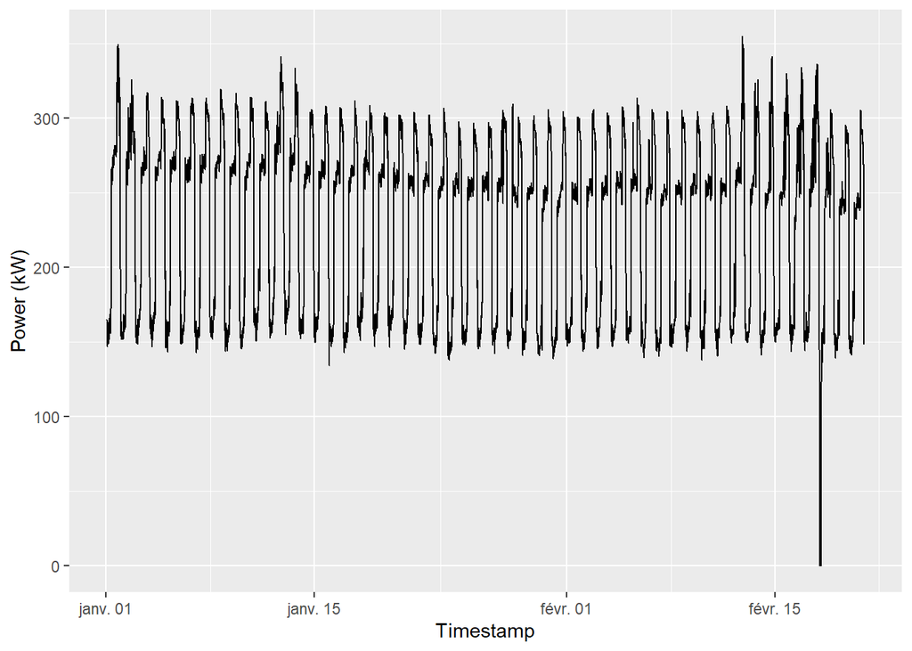

```r
data <- read_excel('2023-11-Elec-train.xlsx')
data$Timestamp <- as.POSIXct(data$Timestamp, format="%m/%d/%Y %H:%M")
specific_time <- as.POSIXct("2010-02-21 00:00:00", format="%Y-%m-%d %H:%M:%S") # here am just storing the value of the last week
data<-data%>%filter(Timestamp < specific_time)


# this new row i added it because there was a problem in the excel file of the first value so i just added manualy since it's only one row.
new_row <- data.frame(
  Timestamp = as.POSIXct("2010-01-01 01:15:00", format="%Y-%m-%d %H:%M:%S"),
  `Power (kW)` = 165.1,
  `Temp (C°)` = 10.6,
  check.names = FALSE
)

data <- bind_rows(data, new_row)

# Extract the relevant subset of the data
data_subset <- data %>%
  arrange(Timestamp) %>%
  select(Timestamp, `Power (kW)`)

data_subset%>%ggplot(aes(x=Timestamp,y=`Power (kW)`))+geom_line()
```

```r
data_subset%>%filter(`Power (kW)`== 0)
```

```
## # A tibble: 11 × 2
##    Timestamp           `Power (kW)`
##    <dttm>                     <dbl>
##  1 2010-02-18 00:00:00            0
##  2 2010-02-18 00:15:00            0
##  3 2010-02-18 00:30:00            0
##  4 2010-02-18 00:45:00            0
##  5 2010-02-18 01:00:00            0
##  6 2010-02-18 01:15:00            0
##  7 2010-02-18 01:30:00            0
##  8 2010-02-18 01:45:00            0
##  9 2010-02-18 02:00:00            0
## 10 2010-02-18 02:15:00            0
## 11 2010-02-18 02:30:00            0
```

```r
##daily seasonality
```

## Comments and Analysis

for now the solution is to impute the 0

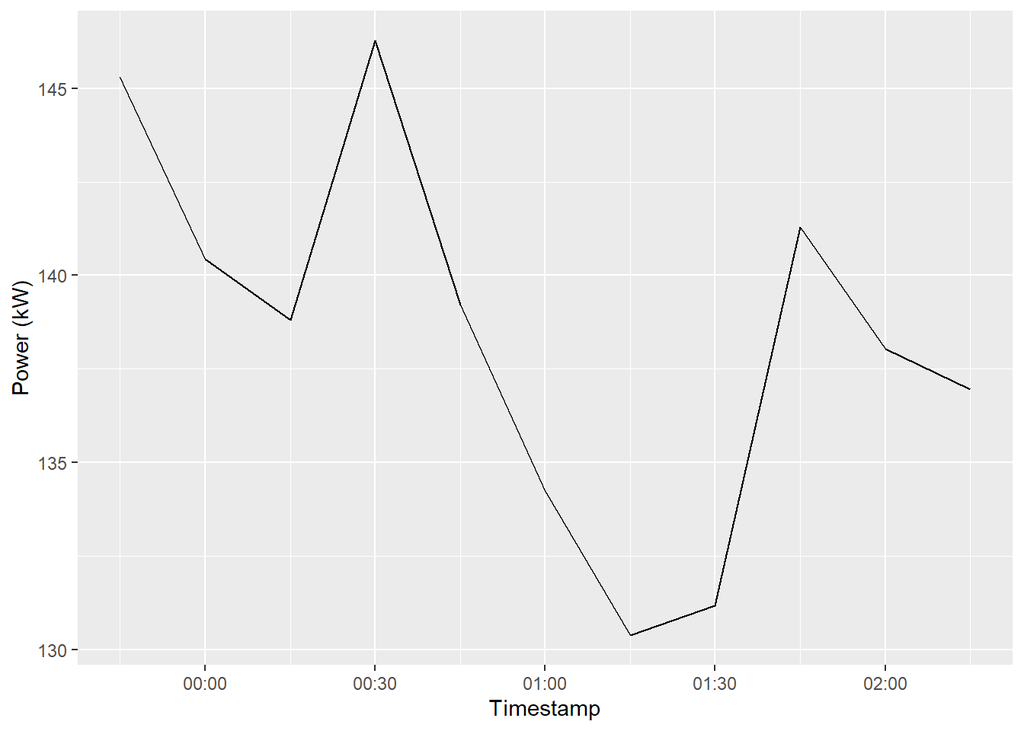

```r
data_subset[data_subset == 0] <- NA
data_subset <- data_subset %>%
  mutate(`Power (kW)` = na_seadec(`Power (kW)`, find_frequency = TRUE))

data_subset%>%filter(Timestamp>='2010-02-17 23:45:00' & Timestamp<= '2010-02-18 02:15:00')%>%ggplot(aes(x=Timestamp,y=`Power (kW)`))+geom_line()
```

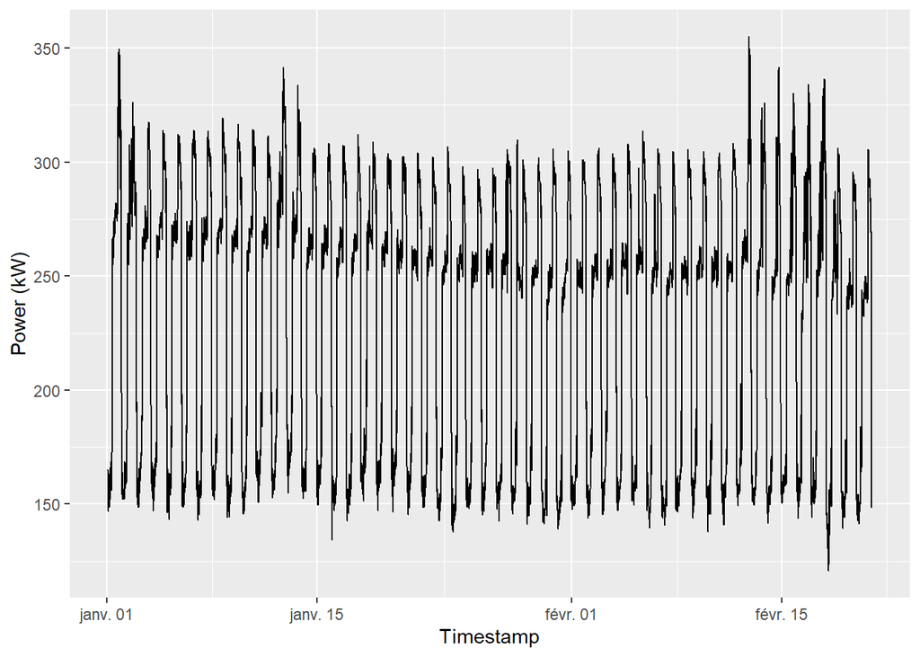

```r
data_subset%>%ggplot(aes(x=Timestamp,y=`Power (kW)`))+geom_line()
```

```r
electricity <- ts(data_subset$`Power (kW)`, start=c(1,5), end=c(51,95), frequency=96)
```

## Comments and Analysis

- for the first plot is just to see if the imputation worked.
- the second plot is another check to see the imputation and it worked very well.
- i tried to create a ts object here and what i suggest is that for every 15 mins is a the unit for me so i will use the frequency 96 mins which is a day with mins.

# time series models

## EXP Smoothing

we will start by splitting the data

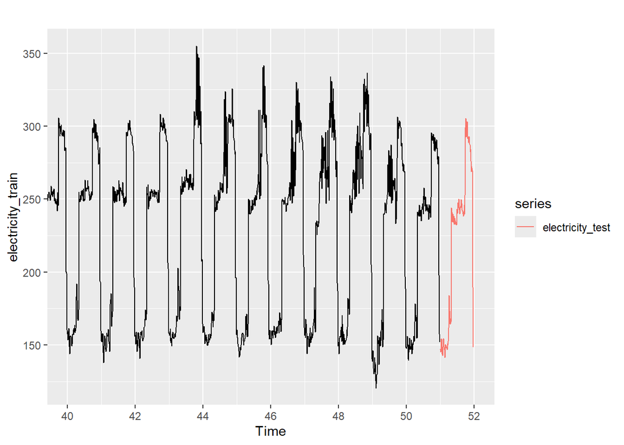

```r
electricity_train=window(electricity,start=c(1,5),end=c(50,96))
electricity_test=window(electricity,start=c(51,1),end=c(51,95))

autoplot(electricity_train)+
  autolayer(electricity_test)+
  coord_cartesian(xlim = c(40, 52))
```

there are two exx smoothing models that we need to try. first one is exp smoothing with additive seasonality without damped and with damped.

##without damped

```r
fit1=hw(electricity_train,seasonal='additive',h=95,damped = FALSE)
```

```
## Error in ets(x, "AAA", alpha = alpha, beta = beta, gamma = gamma, phi = phi, : Frequency too high
```

since the seasonlity is really high, we cannot use the Holt-Winters because we need to estimate 96 initial states for the seasonality component. This will overfit hopelessly. hence we have two options:

- we don’t use Holt-winters in the competition at all.
- we use another frequency by aggregating the data to hourly data and then compare it with other models (even when aggregating the model should perform better if not means we can confirme that we can not use the holt-Winters for this case)

aggregating the data

```r
data_subset_hourly <- data_subset %>%
  mutate(hour=hour(Timestamp))%>%
  mutate(month=month(Timestamp))%>%
  mutate(day=day(Timestamp))%>%
  group_by(month,day,hour) %>%
  summarise(
    `Power (kW)` = sum(`Power (kW)`, na.rm = TRUE),
    Timestamp = min(Timestamp)
  )
```

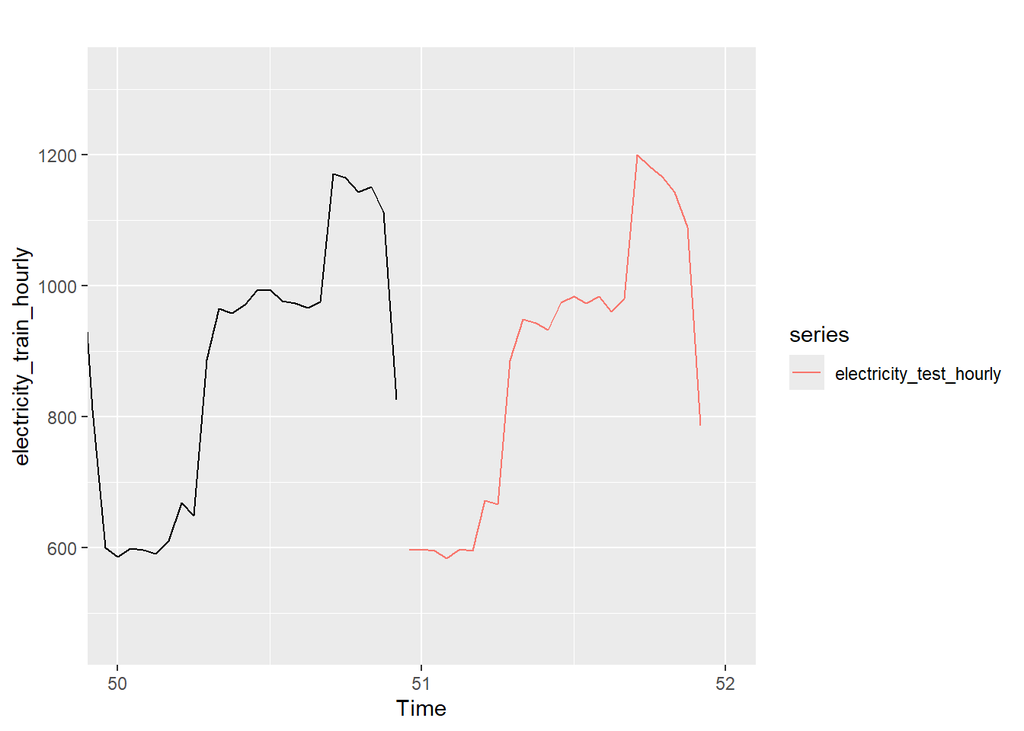

```r
electricity_hourly <- ts(data_subset_hourly$`Power (kW)`, frequency = 24, start = c(1, 1),end=c(51,23))
# Split the data
electricity_train_hourly <- window(electricity_hourly, start = c(1, 1), end = c(50,23))
electricity_test_hourly <- window(electricity_hourly, start = c(51,0),end=c(51,23))

autoplot(electricity_train_hourly) +
  autolayer(electricity_test_hourly)+
  coord_cartesian(xlim = c(50, 52))
```

## Comments : the process of the TS object and the split is the same as using data with 15mins now the frequency is 24h.

let’s proceed with the holt-Winters but hourly

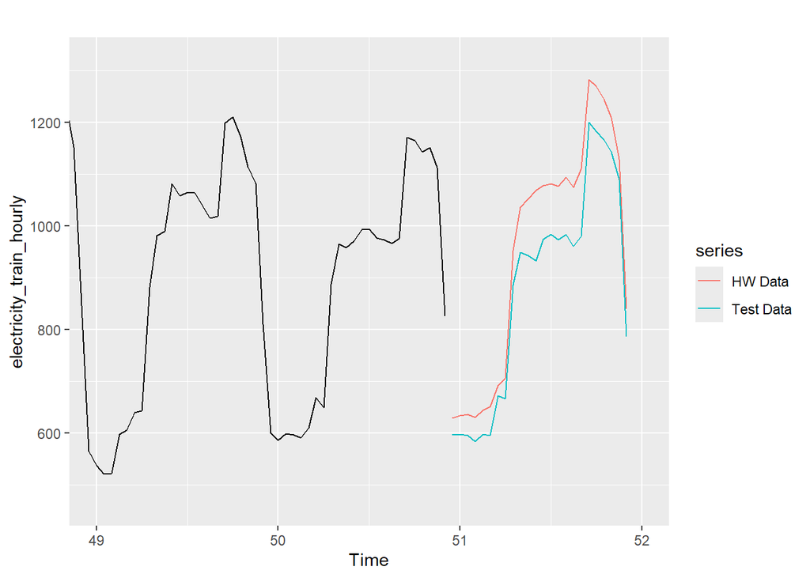

```r
# Exponential Smoothing with additive seasonality without damped trend
fit1 <- hw(electricity_train_hourly, seasonal = 'additive', h = 24, damped = FALSE)

# Plot the forecast
autoplot(electricity_train_hourly) +
  autolayer(fit1$mean, series = "HW Data") +
  autolayer(electricity_test_hourly, series = "Test Data") +
  coord_cartesian(xlim = c(49, 52))
```

## Comments and Anlaysis

- At first glimpse we can see that the HW without damped is performing good but not really well between the hour 51.30h and 51.75h.

## with damped

let’s try with HW with damped

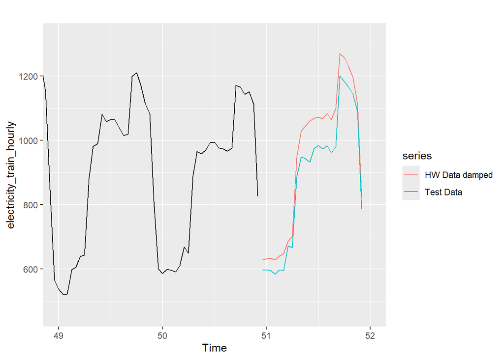

```r
fit2 <- hw(electricity_train_hourly, seasonal = 'additive', h = 24, damped = TRUE)

# Plot the forecast
autoplot(electricity_train_hourly) +
  autolayer(fit2$mean, series = "HW Data damped") +
  autolayer(electricity_test_hourly, series = "Test Data") +
  coord_cartesian(xlim = c(49, 52))
```

to be honest i dont see a big diffrence in the plot let’s print the metrics for both of the models.

```r
print(sqrt(mean((fit1$mean-electricity_test_hourly)^2)))
```

```
## [1] 81.04663
```

```r
print(sqrt(mean((fit2$mean-electricity_test_hourly)^2)))
```

```
## [1] 72.84607
```

the metric is showing a slight better model with damped but both models are close to each other.

let’s use the cross validation and confirm what is the best model

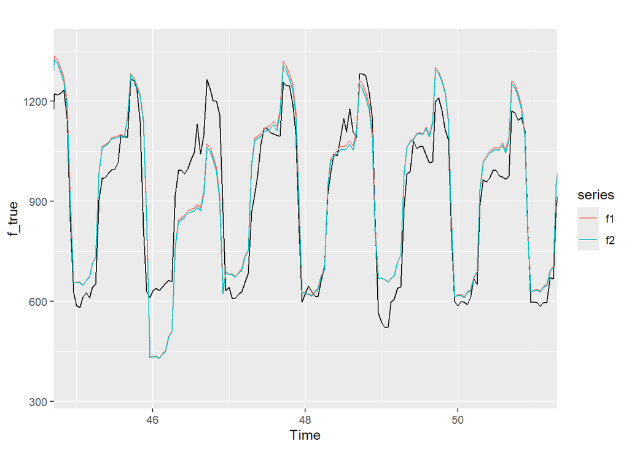

```r
forecasting_1=NULL
forecasting_2=NULL
for (day in 50:3){
  electricity_train_hourly=window(electricity_hourly,start=c(1,1),end=c(day,23))
  h=hw(electricity_train_hourly,seasonal='additive',h=24)
  forecasting_1=c(h$mean,forecasting_1)
  h=hw(electricity_train_hourly,seasonal='additive',damped=TRUE,h=24)
  forecasting_2=c(h$mean,forecasting_2)
}
f_true=window(electricity_hourly,start=c(4,0),end=c(51,23))
f1=ts(forecasting_1,start=c(4,0),end=c(51,23),frequency = 24)
f2=ts(forecasting_2,start=c(4,0),end=c(51,23),frequency = 24)

autoplot(f_true) +
  coord_cartesian(xlim = c(45, 51)) +
  autolayer(f1) +
  autolayer(f2)
```

```r
cat('MAPE for additive HW without damping:',100*mean(abs(forecasting_1-f_true)/f_true),'\n')
```

```
## MAPE for additive HW without damping: 8.328642
```

```r
cat('MAPE for additive HW with damping:',100*mean(abs(forecasting_2-f_true)/(f_true)),'\n')
```

```
## MAPE for additive HW with damping: 7.761679
```

- for the historical forecasting there is alot of anomalies that needs to be fixed
- even after using the cross validation there is not a really big diffrence my intuition is saying this data is not suited for EXP smoothing.

# Sarima models

i will start directly with the auto arima directly so we can confirm that the exp smoothing is not suited for the data

```r
electricity_train_hourly <- window(electricity_hourly, start = c(1, 1), end = c(50,23))
electricity_test_hourly <- window(electricity_hourly, start = c(51,0),end=c(51,23))

fitAuto<-auto.arima(electricity_train_hourly)
prevAutoSARIMA=forecast(fitAuto,h=24)
```

```r
sqrt(mean((prevAutoSARIMA$mean - electricity_test_hourly)^2))
```

```
## [1] 30.54622
```

the auto arima is better than the HW models…

## improve AUTO ARIMA

doing it now with 15 mins data

```r
electricity_train=window(electricity,start=c(1,5),end=c(50,96))
electricity_test=window(electricity,start=c(51,1),end=c(51,95))

fitAuto<-auto.arima(electricity_train)
prevAutoSARIMA=forecast(fitAuto,h=96)
```

let’s try to improve the auto Arima if it’s possible.

first let’s see what the auto arima model gave us.

```r
fitAuto
```

```
## Series: electricity_train
## ARIMA(5,0,0)(0,1,0)[96]
##
## Coefficients:
##          ar1     ar2     ar3      ar4     ar5
##       0.6704  0.0658  0.1614  -0.2818  0.1338
## s.e.  0.0144  0.0170  0.0168   0.0170  0.0144
##
## sigma^2 = 122.9:  log likelihood = -17973.19
## AIC=35958.38   AICc=35958.4   BIC=35997.11
```

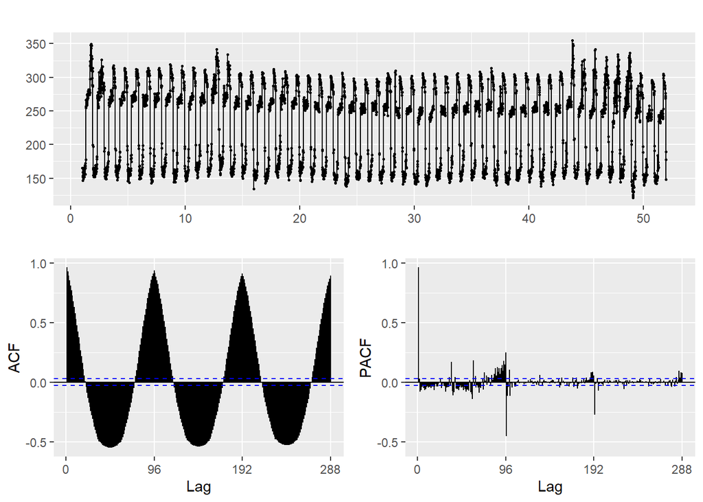

```r
ggtsdisplay(electricity)
```

after the first glimpse there obviously a seasonlity with a lag of 24h (daily seasonality)

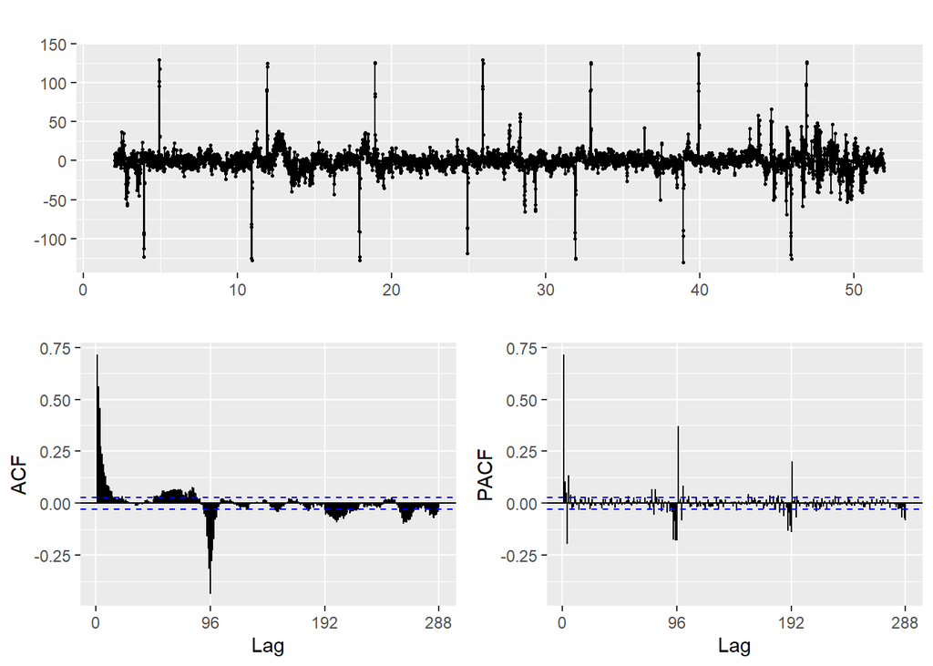

```r
ggtsdisplay(diff(electricity,lag=96))
```

after the first diff on the seasonal part tbh i dont like it alot because there are some peaks it’s like i dont feel the serie dont depend on time analysing the ACF and the PACF there is expontial on the PACF plt with a really important signficance on the first lag of the seasonal part (slag=96) yet somehow i feel there is not a stable variance and mean by time

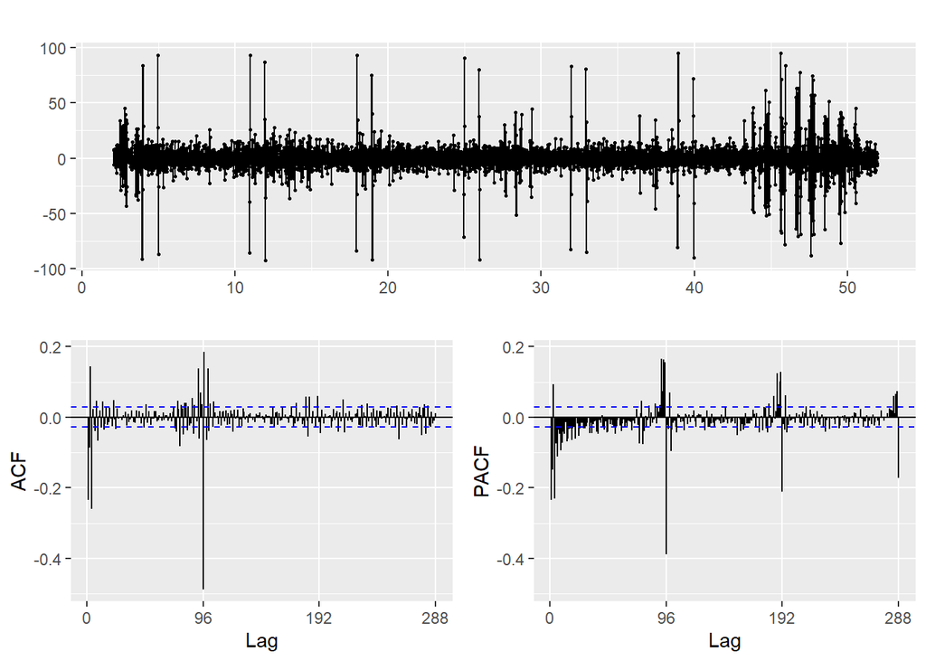

```r
ggtsdisplay(diff(diff(electricity,lag=96)))
```

now i feel it’s more better, there is only one thing to consider there is cyclic peaks that are happening am thinking they are outliers but signficant onse why because maybe when it’s so hot people attend to stay home more and use AC for example i guess thats why you gave us the weather data ;)

```r
fit_arima_M1<-Arima(electricity_train,order = c(0,1,1),seasonal = c(0,1,1))
prevSARIMA_M1=forecast(fit_arima_M1,h=96)

fit_arima_M2<-Arima(electricity_train,order = c(1,1,4),seasonal = c(0,1,1))
prevSARIMA_M2=forecast(fit_arima_M2,h=96)
```

for the first model i put the first param on the diffrencation of the seasonal part. there is also a clearly seasonal expo decrease with frequency of 96 in PACF and theere is only the 96 lag that is significant thats why we use (0,1,1) on the seasonal part of the our model (there is the 192 lag that is significnats but not that much) the non seasonal part we use the same because there is expon decrease on the ACF part and only the first lag just to try to have a simplest model

for the second model we add more the auto regresive part at all and i took into account the first 4 , so i left the seasonal part as it is and the change the non seasonal part to (1,1,4) because i dont to complex more the model.

let’s precced with the plots comparing it to the test set

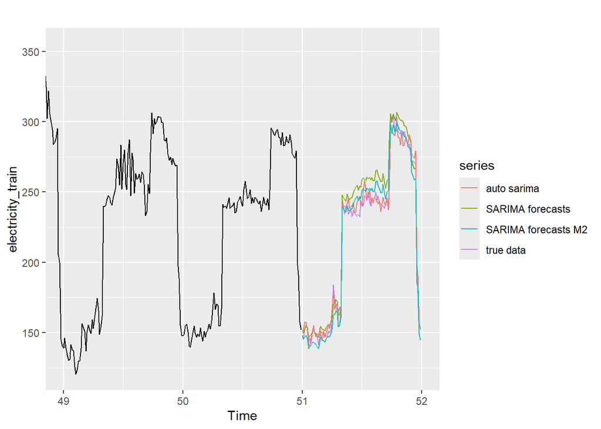

```r
autoplot(electricity_train) + autolayer(electricity_test, series="true data")+
  autolayer(prevSARIMA_M1$mean, series="SARIMA forecasts")+
  autolayer(prevAutoSARIMA$mean, series='auto sarima')+
  autolayer(prevSARIMA_M2$mean, series="SARIMA forecasts M2")+
  coord_cartesian(xlim = c(49, 52))
```

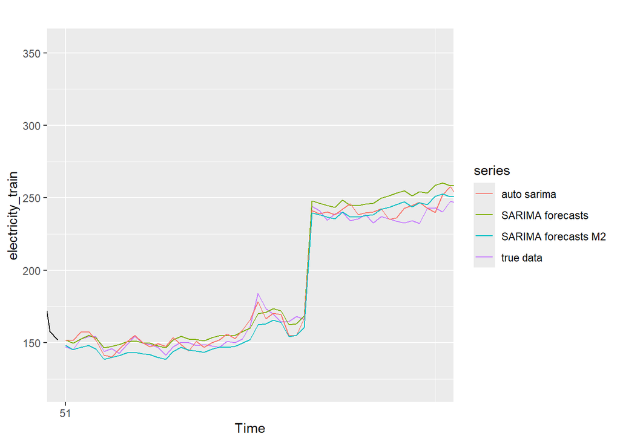

```r
autoplot(electricity_train) + autolayer(electricity_test, series="true data")+
  autolayer(prevSARIMA_M1$mean, series="SARIMA forecasts")+
  autolayer(prevAutoSARIMA$mean, series='auto sarima')+
  autolayer(prevSARIMA_M2$mean, series="SARIMA forecasts M2")+
  coord_cartesian(xlim = c(51, 51.5))
```

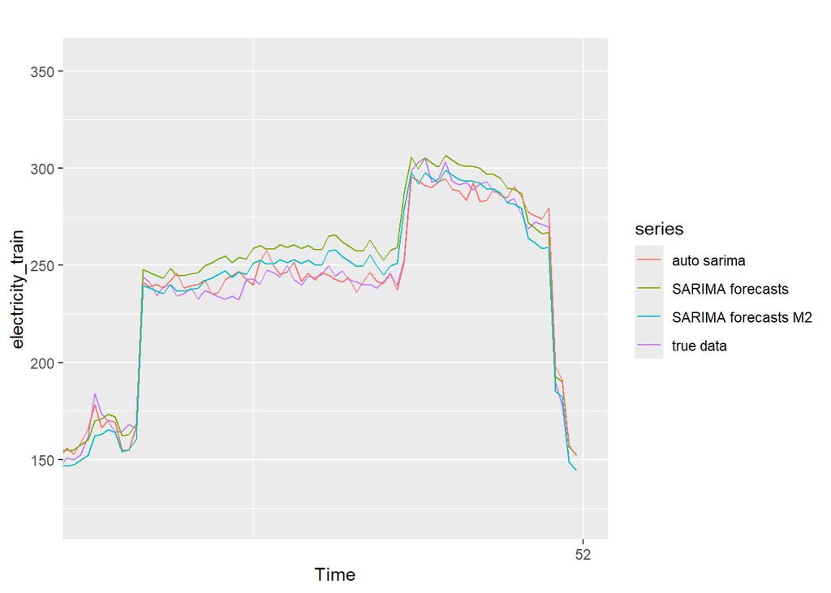

```r
autoplot(electricity_train) + autolayer(electricity_test, series="true data")+
  autolayer(prevSARIMA_M1$mean, series="SARIMA forecasts")+
  autolayer(prevAutoSARIMA$mean, series='auto sarima')+
  autolayer(prevSARIMA_M2$mean, series="SARIMA forecasts M2")+
  coord_cartesian(xlim = c(51.25, 52))
```

- the third plot is the second part of the forecasting, we can notice that M2 is always the better one but some 15 mins the auto arima is more closer to the true data.
- in conculision the M2 and sarima M2 are so close to each other.

let’s confirme this with the metric rmse

```r
# Calculate RMSE for each model


# Create a dataframe to store RMSE and AIC values
results_df <- data.frame(
  Model = c("Auto SARIMA", "SARIMA M1", "SARIMA M2"),
  RMSE = c(rmse_auto_sarima, rmse_sarima_m1, rmse_sarima_m2),
  AIC = c(AIC(fitAuto), AIC(fit_arima_M1), AIC(fit_arima_M2))
)
results_df
```

```
##         Model      RMSE      AIC
## 1 Auto SARIMA  9.929043 35958.38
## 2   SARIMA M1 11.185331 33855.97
## 3   SARIMA M2  7.686210 33330.37
```

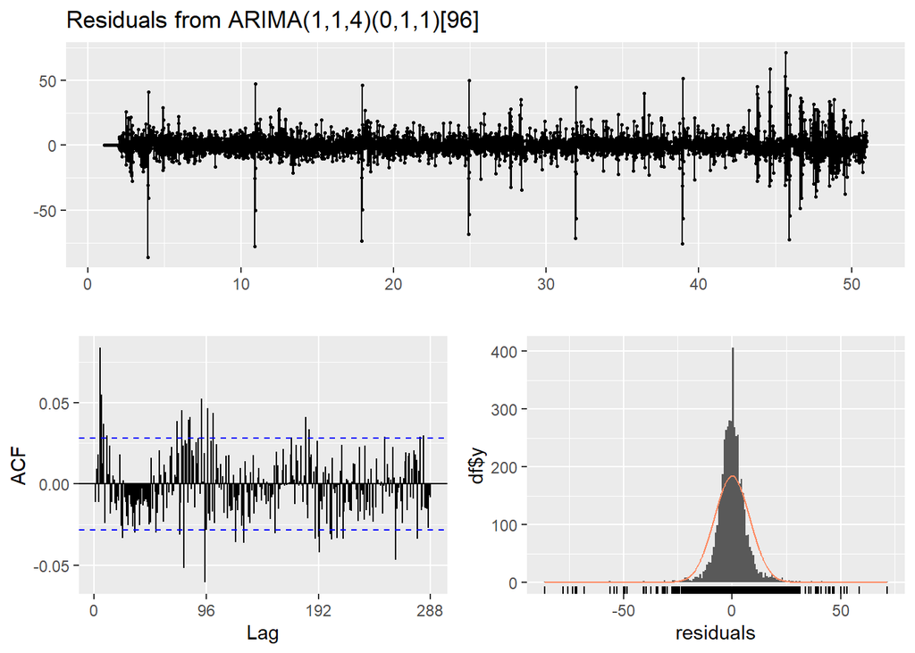

```
##
##  Ljung-Box test
##
## data:  Residuals from ARIMA(1,1,4)(0,1,1)[96]
## Q* = 394.86, df = 186, p-value < 2.2e-16
##
## Model df: 6.   Total lags used: 192
```

```r
checkresiduals(fit_arima_M2)
```

for this part of lot of the models i would choose the SARIMA M2 with order = c(1,1,4),seasonal = c(0,1,1)

let’s try now other models that are not stastics models.

# Random forest

## preparing the data for regression

```r
data_reg=as.vector(electricity_train)[1:13]
for (i in 1:(length(as.vector(electricity_train))-13)){
data_reg=rbind(data_reg,as.vector(electricity_train)[(i+1):(i+13)])
}

head(data_reg)
```

```
##           [,1]  [,2]  [,3]  [,4]  [,5]  [,6]  [,7]  [,8]  [,9] [,10] [,11]
## data_reg 165.1 151.6 146.9 153.7 153.8 159.0 157.7 163.2 151.7 148.7 155.1
##          151.6 146.9 153.7 153.8 159.0 157.7 163.2 151.7 148.7 155.1 161.5
##          146.9 153.7 153.8 159.0 157.7 163.2 151.7 148.7 155.1 161.5 161.5
##          153.7 153.8 159.0 157.7 163.2 151.7 148.7 155.1 161.5 161.5 162.0
##          153.8 159.0 157.7 163.2 151.7 148.7 155.1 161.5 161.5 162.0 166.0
##          159.0 157.7 163.2 151.7 148.7 155.1 161.5 161.5 162.0 166.0 159.0
##          [,12] [,13]
## data_reg 161.5 161.5
##          161.5 162.0
##          162.0 166.0
##          166.0 159.0
##          159.0 158.6
##          158.6 152.1
```

## comments and Analysis

```r
library(randomForest)
library(e1071)
library("xgboost")
fitXgboost<- xgboost(data = data_reg[,1:12], label = data_reg[,13],
max_depth = 10, eta = .5, nrounds = 100,
nthread = 2, objective = "reg:squarederror")
```

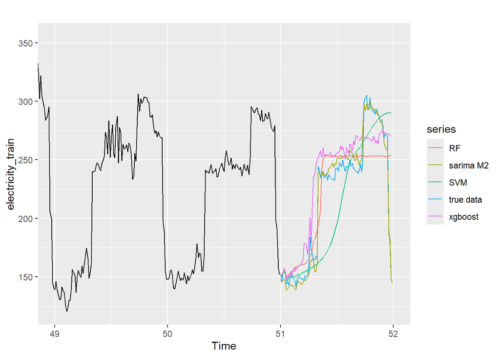

```r
fitRF=randomForest(x=data_reg[,-13], y=data_reg[,13])
fitSVM=svm(x=data_reg[,-13], y=data_reg[,13])

predRF=rep(NULL,96)
predSVM=rep(NULL,96)
predXgboost=rep(NULL,96)
newdataRF=tail(electricity_train,12)
newdataSVM=tail(electricity_train,12)
newdataXgboost=tail(electricity_train,12)


for (t in 1:96){
predRF[t]=predict(fitRF,newdata=newdataRF)
predSVM[t]=predict(fitSVM,newdata=matrix(newdataSVM,1,12))
predXgboost[t]=predict(fitXgboost,matrix(newdataXgboost,1,12))

newdataRF=c(newdataRF[-1],predRF[t])
newdataSVM=c(newdataSVM[-1],predSVM[t])
newdataXgboost=c(newdataXgboost[-1],predXgboost[t])
}

prevRF=ts(predRF,start=c(51,1),end=c(51,95),frequency = 96)
prevSVM=ts(predSVM,start=c(51,1),end=c(51,95),frequency = 96)
prevXgboost=ts(predXgboost,start=c(51,1),end=c(51,95),frequency = 96)



autoplot(electricity_train) + autolayer(electricity_test, series="true data")+
  autolayer(prevSARIMA_M2$mean, series='sarima M2')+
  autolayer(prevRF,series="RF")+
  autolayer(prevSVM,series="SVM")+
  autolayer(prevXgboost,series="xgboost")+
  coord_cartesian(xlim = c(49, 52))
```

- from the plot we can see that both random forest and svm are not performing better than sarima M2 let’s confime with the metric about the xgboost

```r
print(sqrt(mean((prevRF - electricity_test)^2)))
```

```
## [1] 25.85197
```

```r
print(sqrt(mean((prevSVM-electricity_test)^2)))
```

```
## [1] 36.8936
```

```r
print(sqrt(mean((prevXgboost-electricity_test)^2)))
```

```
## [1] 29.92807
```

- we can notice that the only model that is performing good with the Sarima M2

the best model so far is the Sarima when using only the energy consumption without the weather variable

## forecasting with coveriate outdoor temperature

#ARIMA order = c(1,1,4),seasonal = c(0,1,1)

```r
data <- read_excel('2023-11-Elec-train.xlsx')
data$Timestamp <- as.POSIXct(data$Timestamp, format="%m/%d/%Y %H:%M")
specific_time <- as.POSIXct("2010-02-21 00:00:00", format="%Y-%m-%d %H:%M:%S") # here am just storing the value of the last week
data<-data%>%filter(Timestamp < specific_time)


# this new row i added it because there was a problem in the excel file of the first value so i just added manualy since it's only one row.
new_row <- data.frame(
  Timestamp = as.POSIXct("2010-01-01 01:15:00", format="%Y-%m-%d %H:%M:%S"),
  `Power (kW)` = 165.1,
  `Temp (C°)` = 10.6,
  check.names = FALSE
)

data_cov <- bind_rows(data, new_row)
```

```r
electricity <- ts(data_cov, start=c(1,5), end=c(51,95), frequency=96)
```

```r
electricity_train=window(electricity,start=c(1,5),end=c(50,96))
electricity_test=window(electricity,start=c(51,1),end=c(51,95))
```

```r
fit_sarima_m2_with_cov<-Arima(electricity_train[,2],xreg=electricity_train[,3],order = c(1,1,4),seasonal = c(0,1,1))
```

```r
prev_sarima_m2_with_cov=forecast(fit_sarima_m2_with_cov,xreg=electricity_test[,3],h=96)
```

```r
sqrt(mean((prev_sarima_m2_with_cov$mean - electricity_test[,2])^2))
```

```
## [1] 9.272331
```

- somehow the coveriate did not improve my model it maybe because of the coveriate dont explain much the electricity consumption to confirme that we need to do feature selection and see the most important variables

## genarting the forecasting data for the next day without cov

```r
data_future <- read_excel('2023-11-Elec-train.xlsx')
tail(data_future,n=96)
```

```
## # A tibble: 96 × 3
##    Timestamp      `Power (kW)` `Temp (C°)`
##    <chr>                 <dbl>       <dbl>
##  1 2/21/2010 0:00           NA        11.7
##  2 2/21/2010 0:15           NA        11.7
##  3 2/21/2010 0:30           NA        11.7
##  4 2/21/2010 0:45           NA        11.7
##  5 2/21/2010 1:00           NA        11.7
##  6 2/21/2010 1:15           NA        10.6
##  7 2/21/2010 1:30           NA        10.6
##  8 2/21/2010 1:45           NA        10.6
##  9 2/21/2010 2:00           NA        10.6
## 10 2/21/2010 2:15           NA        10.6
## # ℹ 86 more rows
```

```r
xreg_temp=data_future[,3]
xreg_temp=ts(predXgboost,start=c(52,1),end=c(52,96),frequency = 96)
xreg_temp
```

```
## Time Series:
## Start = c(52, 1)
## End = c(52, 96)
## Frequency = 96
##  [1] 147.1109 151.4311 152.8247 157.4200 154.2864 148.0436 149.1773 151.2336
##  [9] 152.6075 150.2242 152.2129 157.1415 154.6107 157.6413 156.3210 159.1387
## [17] 159.8160 159.8863 162.5965 165.0429 178.1220 178.8437 177.4507 169.1379
## [25] 184.6244 200.5944 178.7201 209.4723 234.8945 237.9011 244.9682 251.1991
## [33] 251.5036 255.5331 257.7432 251.9645 260.4033 253.3781 254.3287 253.7504
## [41] 254.3209 253.8214 256.4423 253.2593 253.3081 254.2040 252.3611 255.0209
## [49] 255.4711 256.4028 256.3834 261.7418 258.5493 261.1850 254.9554 250.3602
## [57] 260.3561 258.4442 255.3555 263.7643 261.6138 258.0331 265.5382 262.8534
## [65] 270.5701 270.9180 268.4556 266.5423 267.1275 270.0096 271.6794 269.3792
## [73] 268.5000 269.1248 268.2537 269.0148 267.7193 266.8122 265.7484 270.0873
## [81] 267.6619 264.3257 266.6879 263.5090 272.2614 272.2887 275.3340 272.2881
## [89] 273.6573 272.7538 272.4884 271.0744 272.5741 270.8722 269.9943 270.2191
```

```r
without_cov <- prevSARIMA_M2$mean
with_cov <-forecast(fit_sarima_m2_with_cov,xreg=xreg_temp,h=96)$mean
results_df_final <- data.frame(without_cov = without_cov, with_cov = with_cov)

library(xlsx)
write.xlsx(results_df_final, file = "results.xlsx",row.names=FALSE)
```